# Methods 4 – Portfolio Assignment 1

*Note: Initials were added to the document as required but group work was done equally together.*

## Study group 8

- Kristian Villebro (KV): 202005289
- Luke Ring (LR): 202009983
- Vyara Krasteva (VK): 202005673
- *Type:* Group assignment
- *Due:* 6 March 2022, 23:59

```
rstan version 2.26.11 (Stan version 2.26.1)
```

[output not shown]

[output not shown]

[output not shown]

[output not shown]

[output not shown]

[output not shown]

```
rethinking (Version 2.21)
```

Okay here is a re-skinned version of some of McElreath’s Exercises.

Have fun :)

Trigger alert for anyone who has recently experienced a pandemic.

*– Peter and Chris*

# Pandemic Exercises

## 1) Testing Efficiency (KV)

Imagine there was a global pandemic.

It’s a bit difficult, I know.

Maybe a new version of the old SARS-CoV turns out to be really infectious, or something like that.

A test is developed that is cheap and quick to use, and the government asks you to determine its efficiency.

To do this, they find X people that they know for sure are infected, and X people that they know for sure are not infected. *NB: This is not always possible. For example, there is an ongoing global pandemic in the real world - maybe you heard of it -where a 100% sure test doesn’t exist, as far as I know. But let’s ignore that. The government finds a wizard who can tell for sure, but he wants a lot of money and he’s really slow too.*

Okay, so X infected people take the test, and X uninfected people take the test. See the results below. P means positive, N means negative.

- Infected:

$$P, N, P, P, N, P, P, N, N, N, P, P, N, P, P, N, N, P, N, P$$

- Uninfected:

$$P, N, N, P, N, P, P, N, N, N, P, N, N, N, N, P, P, N, N, N$$

**A)** Estimate the probabilities of testing positive given that you’re infected, and given that you’re not infected. Use the grid approximation method as in the book. Use a prior you can defend using. Report the full posterior probability distribution for each case (we can do better than just a single value!).

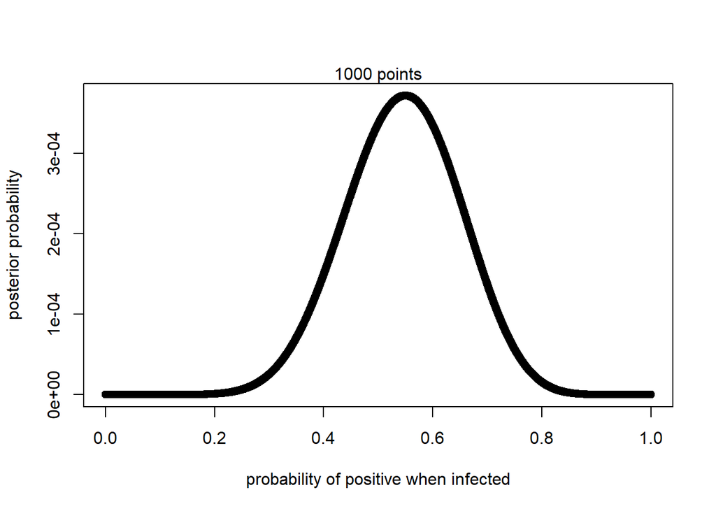

```r
# define grid
p_grid <- seq(from = 0, to = 1, length.out = 1e4)
# define prior
prior <- rep(1, length(p_grid))
# compute likelihood at each value in grid
likelihood <- dbinom(11, size = 20, prob = p_grid)
# compute product of likelihood and prior
unstd.posterior <- likelihood * prior
# standardize the posterior, so it sums to 1
posterior <- unstd.posterior / sum(unstd.posterior)


plot(p_grid, posterior,
    type = "b",
    xlab = "probability of positive when infected",
    ylab = "posterior probability"
)
mtext("1000 points")
```

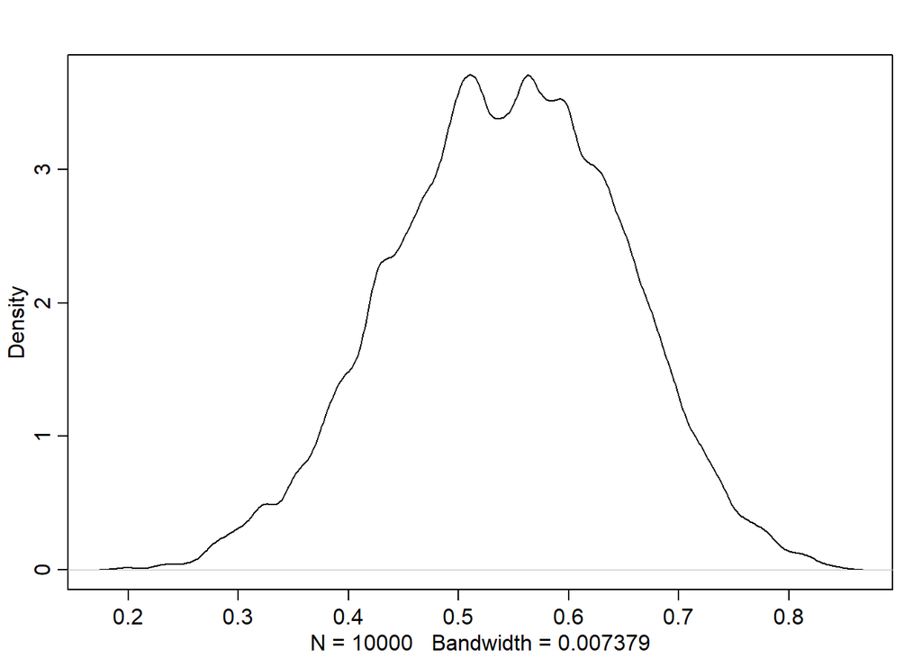

```r
samples_pos_infected <- sample(p_grid, prob = posterior, size = 1e4, replace = TRUE)

dens(samples_pos_infected)
```

```r
# quantiles
quantile(samples_pos_infected, c(0.025, 0.975))
```

```
     2.5%     97.5%
0.3352285 0.7376763
```

```r
# point estimates
mean(samples_pos_infected)
```

```
[1] 0.5435993
```

```r
median(samples_pos_infected)
```

```
[1] 0.5458046
```

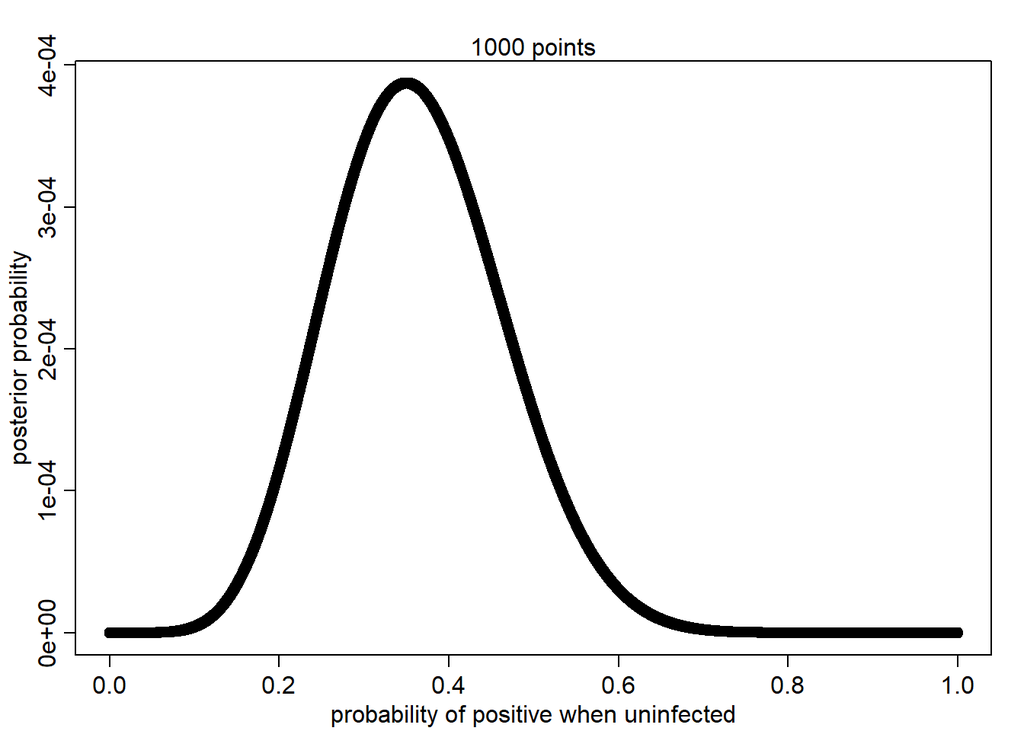

```r
# define grid
p_grid <- seq(from = 0, to = 1, length.out = 1e4)
# define prior
prior <- rep(1, length(p_grid))
# compute likelihood at each value in grid
likelihood <- dbinom(7, size = 20, prob = p_grid)
# compute product of likelihood and prior
unstd.posterior <- likelihood * prior
# standardize the posterior, so it sums to 1
posterior <- unstd.posterior / sum(unstd.posterior)


plot(p_grid, posterior,
    type = "b",
    xlab = "probability of positive when uninfected",
    ylab = "posterior probability"
)
mtext("1000 points")
```

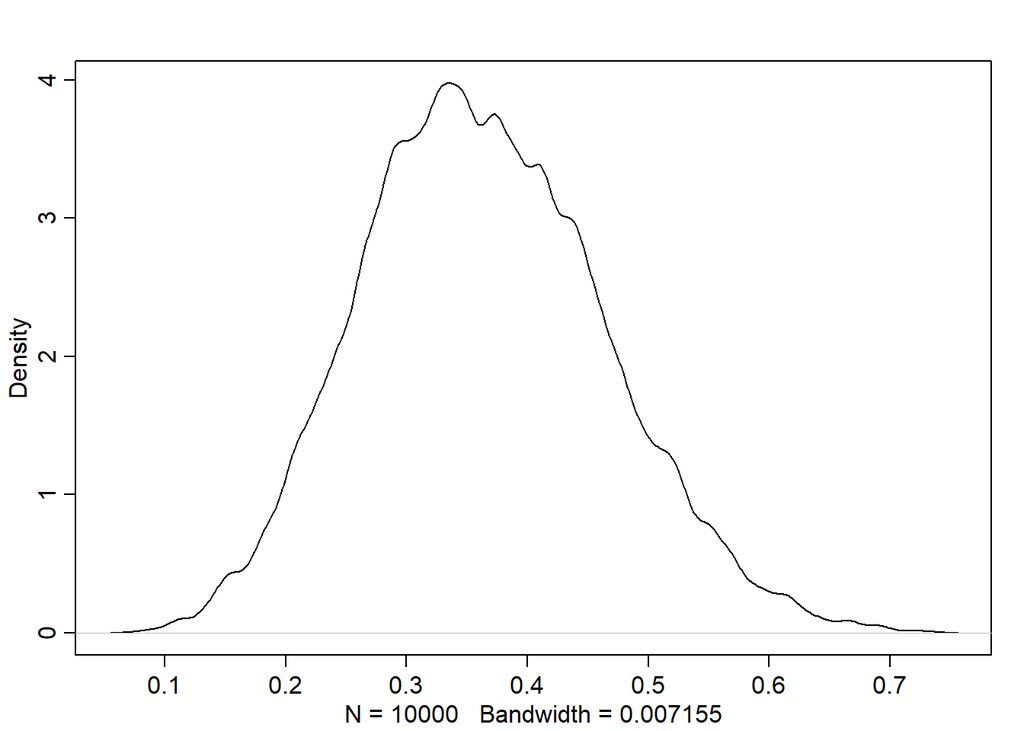

```r
samples_pos_uninfected <- sample(
    p_grid,
    prob = posterior,
    size = 1e4,
    replace = TRUE)

dens(samples_pos_uninfected)
```

```r
quantile(samples_pos_uninfected, c(0.025, 0.975))
```

```
     2.5%     97.5%
0.1816182 0.5706621
```

```r
mean(samples_pos_uninfected)
```

```
[1] 0.3637468
```

```r
median(samples_pos_uninfected)
```

```
[1] 0.3583358
```

**B)** The government says that they find probability distributions difficult to use. They ask you to provide them with a confidence interval of 95% within which the ‘real’ probability can be found. Do it.

```r
# after telling the government that 95% CI is a bad idea,
# they tell the research team that they know better
# and ask for a 95% CI anyway. Considering the risk of being replaced
# by yes-men and lackies (we calculated this with bayesian statistics)
# in the past, we decided to go ahead and do what they ask,
# and hope that we can sneak in warnings and caveats before
# the press gets hold of these data.
quantile(samples_pos_infected, c(0.025, 0.975))
```

```
     2.5%     97.5%
0.3352285 0.7376763
```

```r
quantile(samples_pos_uninfected, c(0.025, 0.975))
```

```
     2.5%     97.5%
0.1816182 0.5706621
```

**C)** The government says that their voters find confidence intervals difficult to read. In addition, they are so wide that it looks like the government doesn’t know what they’re doing. They want a point estimate instead. Give them one.

```r
## <<<double check>>>
round(mean(samples_pos_infected), 2)
```

```
[1] 0.54
```

```r
round(mean(samples_pos_uninfected), 2)
```

```
[1] 0.36
```

While we could use the chain mode (most frequent), we decided to take the mean and give them the values of 54% chance of getting a positive test result given that you’re infected and 36% chance of getting a positive test given you are not infected.

## 2) Dark Cellars (LR)

Months pass. Thousands of people are tested by the wizards of the world governments. A fancy company analyses the data, and determine, with very high confidence they say, the probability of testing positive with the current test. They give the following point estimates:

- A 53% chance of testing positive if you are infected.
- A 45% chance of testing positive if you are not infected.

*NB: These numbers also happen to be real estimates for the efficiency of the COVID kviktest[^1]. Remember that the actual Danish government doesn’t have any wizards, though.*

**A)** You are sitting in your dark cellar room, trying to come up with an apology to the Danish government, when you receive a positive test result on your phone. Oh, that party last weekend. In order to fight the boredom of isolation life, you start doing statistical inference. Estimate the probability that you are infected, given that it is *a priori* equally likely to be infected or not to be.

> $Pr(pos | infected_{true}) = 0.53$

> $Pr(pos | infected_{false}) = 0.45$

> $Pr(infected_{true}) = 0.50$

> $Pr(infected_{false}) = 1 - Pr(infected_{true}) = 0.50$

> $$Pr(infected_{true}|pos) = \frac{Pr(pos|infected_{true})Pr(infected_{true})}{Pr(pos|infected_{true})Pr(infected_{true})+Pr(pos|infected_{false})Pr(infected_{false})}$$

> $$= \frac{(0.53)(0.5)}{(0.53)(0.5)+(0.45)(0.5)} = \frac{0.265}{0.265 + 0.225} = \frac{0.265}{0.49} = 0.541$$

> $54.1%$ chance of being infected

**B)** A quick Google search tells you that about 546.000[^2] people in Denmark are infected right now. Use this for a prior instead.

> Population of Denmark: [5,826,219](https://www.worldometers.info/world-population/denmark-population/)

> Infected population: 546,000

```r
(p_data <- 546000 / 5826219)
```

```
[1] 0.09371429
```

```r
(p_infected <- (0.53 * p_data) / (0.53 * p_data + 0.45 * (1 - p_data)))
```

```
[1] 0.1085659
```

> 10.9% chance of being infected

**C)** A friend calls and says that they have been determined by a wizard to be infected. You and your friend danced tango together at the party last weekend. It has been estimated that dancing tango with an infected person leads to an infection 32% of the time[^3]. Incorporate this information in your estimate of your probability of being infected.

```
        P
       / .53
      I
     / \ .47
.32 /   P'
   /
   \
.68 \    P
     \  / .45
      I'
        \ .55
         P'
```

> $Pr(pos | infected_{true}) = 0.53$

> $Pr(pos | infected_{false}) = 0.45$

> Based on the above information we now have an updated prior of our probability of infection.

> $Pr(infected_{true}) = 0.32$

> $Pr(infected_{false}) = 1 - Pr(infected_{true}) = 0.68$

> $$Pr(infected_{true}|pos,tango) = \frac{Pr(pos|infected_{true})Pr(infected_{true})}{Pr(pos|infected_{true})Pr(infected_{true})+Pr(pos|infected_{false})Pr(infected_{false})}$$

> $$= \frac{(0.53)(0.32)}{(0.53)(0.32)+(0.45)(0.68)} = \frac{0.1696}{0.1696 + 0.306} = \frac{0.1696}{0.4756} = 0.3566$$

> $36%$ chance of being infected

**D)** You quickly run and get two more tests. One is negative, the other positive. Update your estimate.

> use something like above, but the prior probability of being infected is now: 36% after,
> $$Pr(infected_{true}|pos,tango,pos)$$

> $Pr(neg | infected_{true}) = 1 - Pr(pos | infected_{true}) = 1 - 0.53 = 0.47$

> $Pr(neg | infected_{false}) = 1 - Pr(pos | infected_{false}) = 1 - 0.45 = 0.55$

**E)** In a questionnaire someone sent out for their exam project, you have to answer if you think you are infected. You can only answer yes or no (a bit like making a point estimate). What do you answer?

> no

**F)** You are invited to a party. They ask if you are infected. They also say that they would prefer if you used an asymmetric loss function when making your decision: it is three times worse to falsely answer not infected, than to falsely answer infected. What do you answer?

> probabilities

> asymmetric loss function

> | answer | infected | not infected |
> | --- | --- | --- |
> | pos | 0 | 1 |
> | neg | 3 | 0 |

> expected loss

> | answer | infected | not infected | loss |
> | --- | --- | --- | --- |
> | pos | 0 | 0.669 | 0.669 |
> | neg | 0.963 | 0 | 0.963 |

> Based on calculated expected loss, we decide to say we are positive, as answering negative has a higher expected loss.

## 3) Causal Models (VK)

A problem from our textbook *Statistical Rethinking (2nd ed.)* (p. 160):

> **5H4.** Here is an open practice problem to engage your imagination. In the divorce data, states in the southern United States have many of the highest divorce rates. Add the `South` indicator variable to the analysis. First, draw one or more DAGs that represent your ideas for how Southern American culture might influence any of the other three variables ($D$, $M$, or $A$). Then list the testable implications of your DAGs, if there are any, and fit one or more models to evaluate the implications. What do you think the influence of “Southernness” is?

> We think that Southern states would have a cultural pressure to get married, and at a younger age (especially in relation to abstinence-only sex eduction) and would both have an effect on the age that people get married as well as the divorce rates (possibly in highly religious communities, divorce might be frowned upon).

> Based on the results found in the book, marriage rate’s effect weren’t so strong and therefore we did not include the marriage rate in this model.

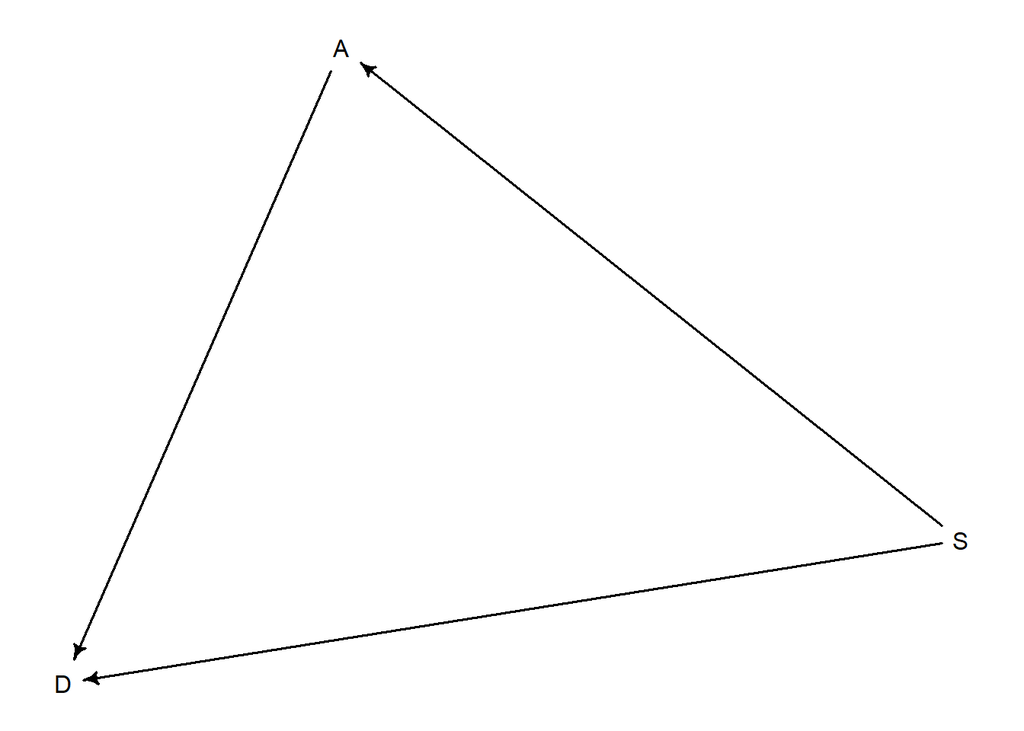

```r
library(dagitty)

data(WaffleDivorce)
d <- WaffleDivorce
rm(WaffleDivorce)

d$D <- standardize(d$Divorce)
d$M <- standardize(d$Marriage)
d$A <- standardize(d$MedianAgeMarriage)

# Make "south" index variable
d$S <- ifelse(d$South == 1, 2, 1)

dag_divorce <- dagitty("dag{
        S -> A
        S -> D <- A}")
drawdag(dag_divorce)
```

### Model

```r
m1 <- quap(
    alist(
        # A -> D <- S
        D ~ dnorm(mu, sigma),
        mu <- a[S] + bA * A,
        a[S] ~ dnorm(0, 0.2),
        bA ~ dnorm(0, 0.5),
        sigma ~ dexp(1)
), data = d)

precis(m1, depth = 2)
```

|  | mean | sd | 5.5% | 94.5% |
| --- | --- | --- | --- | --- |
| a[1] | -0.09223894 | 0.10859361 | -0.26579250 | 0.08131462 |
| a[2] | 0.16283074 | 0.14567136 | -0.06998023 | 0.39564171 |
| bA | -0.54242244 | 0.10899249 | -0.71661349 | -0.36823140 |
| sigma | 0.76817804 | 0.07657288 | 0.64579979 | 0.89055629 |

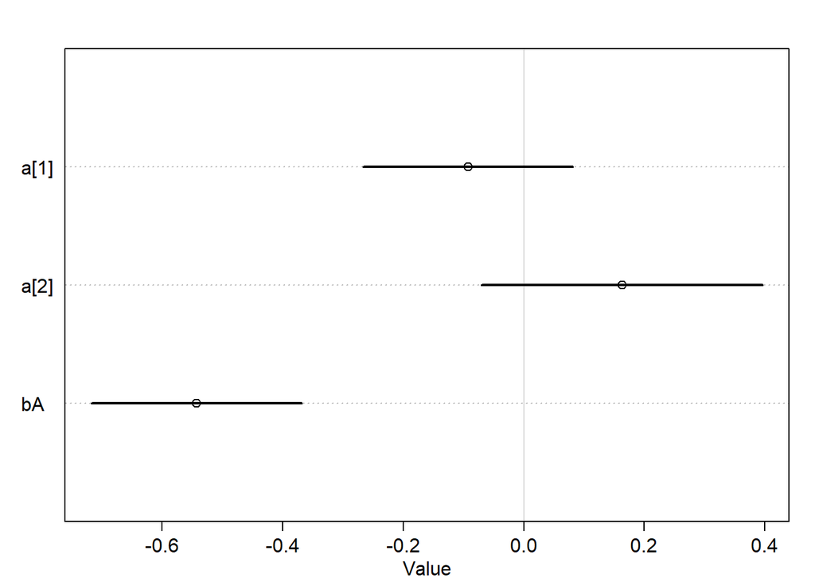

```r
plot(precis(m1, depth = 2, pars = c("bA", "a[1]", "a[2]")))
```

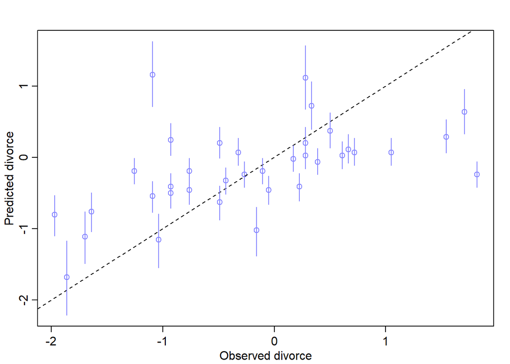

```r
muN <- link(m1, data = d[d$S == 1, ])
muN_mean <- apply(muN, 2, mean)
muN_PI <- apply(muN, 2, PI)
DN_sim <- sim(m1, n = 1e4)
DN_PI <- apply(DN_sim, 2, PI)

muS <- link(m1, data = d[d$S == 2, ])
muS_mean <- apply(muS, 2, mean)
muS_PI <- apply(muS, 2, PI)
DS_sim <- sim(m1, n = 1e4)
DS_PI <- apply(DS_sim, 2, PI)

plot(muN_mean ~ d[d$S == 1, ]$D,
    col = rangi2,
    ylim = range(muN_PI),
    xlab = "Observed divorce",
    ylab = "Predicted divorce")
abline(a = 0, b = 1, lty = 2)

for (i in 1:nrow(d[d$S == 1, ])) {
    lines(rep(d[d$S == 1, ]$D[i], 2), muN_PI[, i], col = rangi2)
}
```

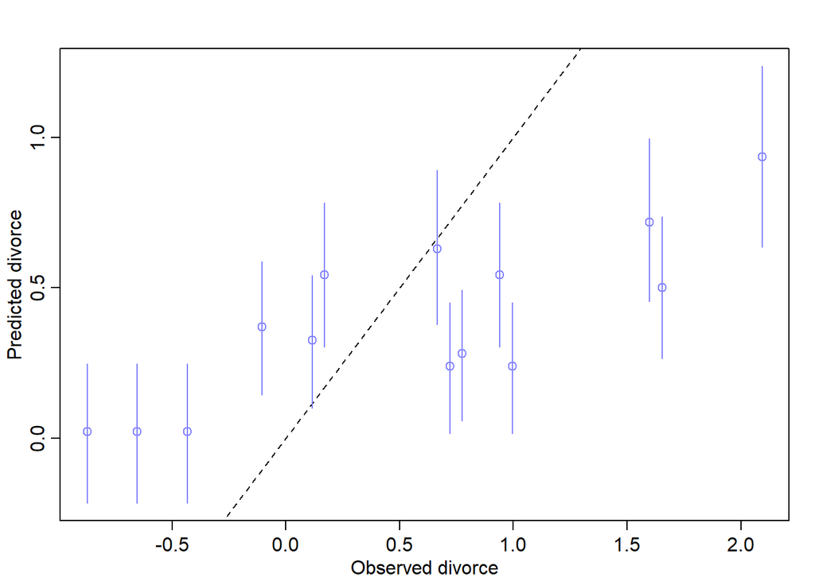

```r
plot(muS_mean ~ d[d$S == 2, ]$D,
    col = rangi2,
    ylim = range(muS_PI),
    xlab = "Observed divorce",
    ylab = "Predicted divorce")
abline(a = 0, b = 1, lty = 2)
for (i in 1:nrow(d[d$S == 2, ])) {
    lines(rep(d[d$S == 2, ]$D[i], 2), muS_PI[, i], col = rangi2)
}
```

> Above we have plotted the posterior predictions compared to the observed divorce rate, the first plot shows the predictions for non-southern states, the second plot shows the predictions for southern states. Because our model only varies the intercept by “southernness” the fit is not ideal, especially for the the southern states.
[^1]: I was lazy and just used this source:

    https://www.ssi.dk/aktuelt/nyheder/2021/antigentest-gav-47-falsk-negative-svar
[^2]: https://www.worldometers.info/coronavirus/#countries
[^3]: That one I just made up.